# Unidad 1 | Mod. Estadísticos para la Toma de Decisiones

Actividad 1 - Evaluación de la Oferta Inmobiliaria Urbana

Juan Alejandro Carrillo Jaimes

22 de agosto de 2026

[figure not shown]

# 1 Descripción

Una empresa inmobiliaria líder en una gran ciudad requiere comprender el mercado de viviendas urbanas disponibles para tomar decisiones estratégicas de compra, venta y valoración de propiedades. Se cuenta con una base de datos con las características de las propiedades ofertadas (precio, área, ubicación, estrato, tipo, entre otras). Este informe primero describe esa base de datos y luego aplica técnicas de análisis multivariado (Componentes Principales, Conglomerados y Correspondencia) con el fin de identificar patrones que soporten esas decisiones.

# 2 Objetivos

## 2.1 Objetivo general

Caracterizar la oferta inmobiliaria urbana mediante estadística descriptiva y técnicas multivariadas, identificando los factores que explican la variación de precios y los segmentos relevantes del mercado para apoyar decisiones de inversión.

## 2.2 Objetivos específicos

1. Describir las variables de la base de datos (tendencia central, dispersión, datos faltantes y valores atípicos) antes de aplicar cualquier técnica multivariada.
2. Reducir la dimensionalidad de las variables cuantitativas de las propiedades mediante Análisis de Componentes Principales (ACP), identificando qué características explican la mayor parte de la variabilidad del mercado.
3. Segmentar las propiedades en grupos homogéneos mediante Análisis de Conglomerados, para caracterizar dinámicas de oferta por zona y estrato.
4. Examinar la asociación entre variables categóricas (tipo de vivienda, zona y barrio) mediante Análisis de Correspondencia.
5. Visualizar los resultados (incluyendo la ubicación geográfica de las propiedades) para comunicar hallazgos y recomendaciones a la dirección de la empresa.

# 3 Datos

La base de datos `vivienda` pertenece al paquete `paqueteMODELOS` del curso y contiene propiedades residenciales ofertadas en la ciudad de Cali, obtenidas mediante *webscraping* de OLX.

```r
# devtools::install_github("centromagis/paqueteMODELOS", force = TRUE)
library(paqueteMODELOS)
library(dplyr)
library(tidyr)
library(ggplot2)
library(gridExtra)
library(knitr)
library(kableExtra)

data(vivienda)
dim(vivienda)
```

```
## [1] 8322   13
```

## 3.1 Renombre de variables

Se renombran las variables originales a nombres cortos y sin tildes ni espacios (en ingles). Esto facilita escribir y leer el código en las secciones siguientes (por ejemplo `price` en vez de `preciom`), y es el nombre que se usará de aquí en adelante tanto en el código como en el texto.

```r
vivienda <- vivienda |>
  rename(
    zone         = zona,
    floor        = piso,
    stratum      = estrato,
    price        = preciom,
    built_area   = areaconst,
    parking      = parqueaderos,
    bathrooms    = banios,
    bedrooms     = habitaciones,
    type         = tipo,
    neighborhood = barrio,
    longitude    = longitud,
    latitude     = latitud
  )
names(vivienda)
```

```
##  [1] "id"           "zone"         "floor"        "stratum"      "price"
##  [6] "built_area"   "parking"      "bathrooms"    "bedrooms"     "type"
## [11] "neighborhood" "longitude"    "latitude"
```

**Tabla 3.1.** Descripción y clasificación de las variables (como se vio en la Unidad 1, sesión de Conceptos Generales, sobre naturaleza cualitativa/cuantitativa de las variables)

```r
# Clasificación de variables: CC=Cuant. Continua, CD=Cuant. Discreta,
# CO=Cualitativa Ordinal, CN=Cualitativa Nominal
variables_df <- data.frame(
  Variable = c("id", "zone", "floor", "stratum", "price", "built_area",
               "parking", "bathrooms", "bedrooms", "type", "neighborhood",
               "longitude", "latitude"),
  Original = c("id", "zona", "piso", "estrato", "preciom", "areaconst",
               "parqueaderos", "banios", "habitaciones", "tipo", "barrio",
               "longitud", "latitud"),
  Descripcion = c(
    "Identificador de la propiedad",
    "Zona de la ciudad (Centro, Norte, Oeste, Oriente, Sur)",
    "Piso del inmueble (aplica a apartamentos)",
    "Estrato socioeconómico",
    "Precio de oferta (millones de pesos)",
    "Área construida (m2)",
    "Número de parqueaderos",
    "Número de baños",
    "Número de habitaciones",
    "Tipo de inmueble (Casa, Apartamento)",
    "Barrio de ubicación",
    "Coordenada de longitud",
    "Coordenada de latitud"
  ),
  Tipo = c("ID", "CN", "CN", "CO", "CC", "CC", "CD", "CD", "CD", "CN", "CN", "CC", "CC")
)

kable(variables_df, col.names = c("Variable", "Nombre original", "Descripción", "Tipo"),
      align = c("l", "l", "l", "c")) |>
  kable_styling(bootstrap_options = c("striped", "hover", "condensed"),
                full_width = TRUE, font_size = 13)
```

| Variable | Nombre original | Descripción | Tipo |
| --- | --- | --- | --- |
| id | id | Identificador de la propiedad | ID |
| zone | zona | Zona de la ciudad (Centro, Norte, Oeste, Oriente, Sur) | CN |
| floor | piso | Piso del inmueble (aplica a apartamentos) | CN |
| stratum | estrato | Estrato socioeconómico | CO |
| price | preciom | Precio de oferta (millones de pesos) | CC |
| built_area | areaconst | Área construida (m2) | CC |
| parking | parqueaderos | Número de parqueaderos | CD |
| bathrooms | banios | Número de baños | CD |
| bedrooms | habitaciones | Número de habitaciones | CD |
| type | tipo | Tipo de inmueble (Casa, Apartamento) | CN |
| neighborhood | barrio | Barrio de ubicación | CN |
| longitude | longitud | Coordenada de longitud | CC |
| latitude | latitud | Coordenada de latitud | CC |

# 4 Fase de Estadística Descriptiva

Antes de aplicar cualquier técnica multivariada se describe el comportamiento individual de las variables, tal como se plantea en la Unidad 1 en la sesión de Conceptos Generales para el análisis univariado.

```r
vars_num <- c("price", "built_area", "parking", "bathrooms", "bedrooms")
```

## 4.1 Medidas de tendencia central

**Tabla 4.1.** Media y mediana de las variables cuantitativas

```r
stats_ct <- data.frame(
  Variable = vars_num,
  Media    = sapply(vars_num, function(v) mean(vivienda[[v]], na.rm = TRUE)),
  Mediana  = sapply(vars_num, function(v) median(vivienda[[v]], na.rm = TRUE))
)

stats_ct |>
  mutate(across(c(Media, Mediana), \(x) round(x, 1))) |>
  kable(align = c("l", "c", "c")) |>
  kable_styling(bootstrap_options = c("striped", "hover"), full_width = FALSE)
```

|  | Variable | Media | Mediana |
| --- | --- | --- | --- |
| price | price | 433.9 | 330 |
| built_area | built_area | 174.9 | 123 |
| parking | parking | 1.8 | 2 |
| bathrooms | bathrooms | 3.1 | 3 |
| bedrooms | bedrooms | 3.6 | 3 |

**Figura 4.1.** Distribución de cada variable cuantitativa, con su media (línea roja) y su mediana (línea azul oscuro)

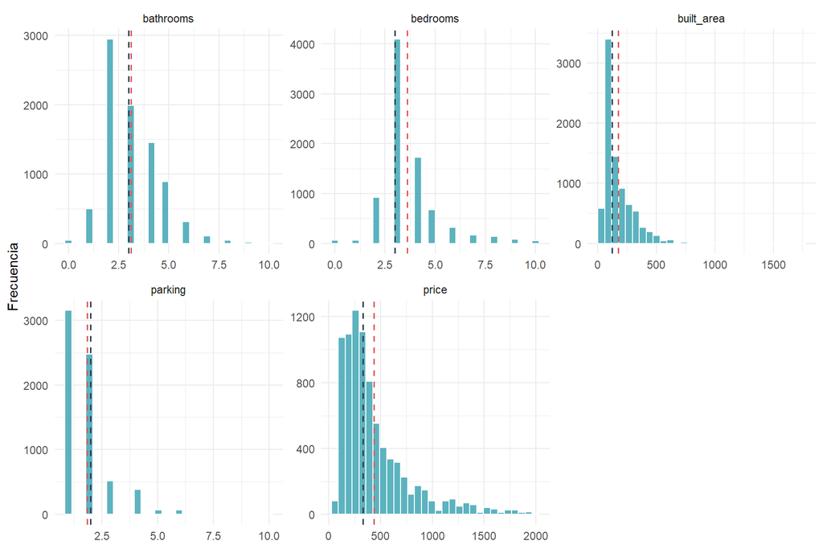

```r
vivienda |>
  select(all_of(vars_num)) |>
  pivot_longer(everything(), names_to = "Variable", values_to = "Valor") |>
  ggplot(aes(x = Valor)) +
  geom_histogram(bins = 30, fill = col_secundario, color = "white", alpha = 0.9) +
  geom_vline(data = stats_ct, aes(xintercept = Media), color = "#E15759",
             linetype = "dashed", linewidth = 0.7) +
  geom_vline(data = stats_ct, aes(xintercept = Mediana), color = "#2C3E50",
             linetype = "dashed", linewidth = 0.7) +
  facet_wrap(~ Variable, scales = "free", ncol = 3) +
  theme_minimal(base_size = 11) +
  labs(x = NULL, y = "Frecuencia")
```

`price` y `built_area` muestran media notablemente mayor que la mediana (la línea roja a la derecha de la azul), lo que confirma asimetría hacia la derecha; en `parking`, `bathrooms` y `bedrooms` ambas líneas están más cercanas.

## 4.2 Medidas de dispersión

**Tabla 4.2.** Desviación estándar, rango, rango intercuartílico (IQR) y coeficiente de variación (CV)

```r
stats_disp <- data.frame(
  Variable = vars_num,
  DE  = sapply(vars_num, function(v) sd(vivienda[[v]], na.rm = TRUE)),
  Min = sapply(vars_num, function(v) min(vivienda[[v]], na.rm = TRUE)),
  Max = sapply(vars_num, function(v) max(vivienda[[v]], na.rm = TRUE)),
  IQR = sapply(vars_num, function(v) IQR(vivienda[[v]], na.rm = TRUE))
) |>
  mutate(CV = round(DE / stats_ct$Media, 2))

stats_disp |>
  mutate(across(c(DE, Min, Max, IQR), \(x) round(x, 1))) |>
  kable(col.names = c("Variable", "Desv. estándar", "Mín", "Máx", "IQR", "CV"),
        align = c("l", rep("c", 5))) |>
  kable_styling(bootstrap_options = c("striped", "hover"), full_width = FALSE)
```

|  | Variable | Desv. estándar | Mín | Máx | IQR | CV |
| --- | --- | --- | --- | --- | --- | --- |
| price | price | 328.6 | 58 | 1999 | 320 | 0.76 |
| built_area | built_area | 143.0 | 30 | 1745 | 149 | 0.82 |
| parking | parking | 1.1 | 1 | 10 | 1 | 0.61 |
| bathrooms | bathrooms | 1.4 | 0 | 10 | 2 | 0.46 |
| bedrooms | bedrooms | 1.5 | 0 | 10 | 1 | 0.40 |

**Figura 4.2.** Coeficiente de variación por variable (mayor barra = mayor dispersión relativa)

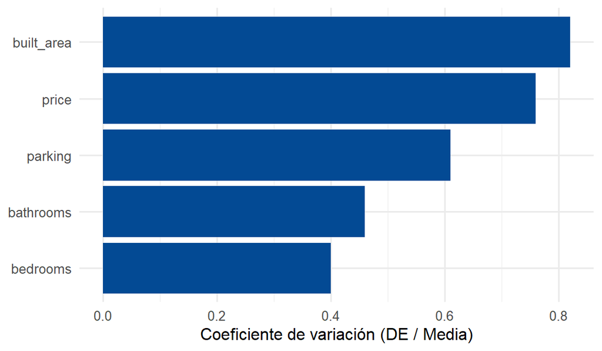

```r
ggplot(stats_disp, aes(x = reorder(Variable, CV), y = CV)) +
  geom_col(fill = col_primario) +
  coord_flip() +
  theme_minimal(base_size = 12) +
  labs(x = NULL, y = "Coeficiente de variación (DE / Media)")
```

`built_area` tiene el coeficiente de variación más alto (0.82), seguido de cerca por `price` (0.76): son las dos variables con mayor dispersión relativa; `bathrooms` y `bedrooms` son las más homogéneas entre propiedades.

## 4.3 Distribución de variables categóricas

**Tabla 4.3.** Frecuencia de propiedades por zona y por tipo de inmueble

```r
zone_counts <- vivienda |> filter(!is.na(zone)) |> count(zone)
type_counts <- vivienda |> filter(!is.na(type)) |> count(type)

zone_counts |>
  kable(col.names = c("Zona", "N"), align = c("l", "c")) |>
  kable_styling(bootstrap_options = c("striped", "hover"), full_width = FALSE)
```

| Zona | N |
| --- | --- |
| Zona Centro | 124 |
| Zona Norte | 1920 |
| Zona Oeste | 1198 |
| Zona Oriente | 351 |
| Zona Sur | 4726 |

```r
type_counts |>
  kable(col.names = c("Tipo", "N"), align = c("l", "c")) |>
  kable_styling(bootstrap_options = c("striped", "hover"), full_width = FALSE)
```

| Tipo | N |
| --- | --- |
| Apartamento | 5100 |
| Casa | 3219 |

**Figura 4.3.** Número de propiedades por zona (izquierda) y por tipo de inmueble (derecha)

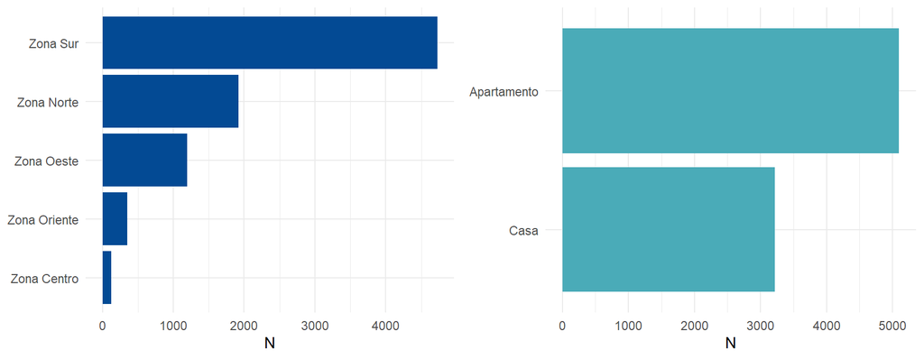

```r
p_zone <- ggplot(zone_counts, aes(x = reorder(zone, n), y = n)) +
  geom_col(fill = col_primario) + coord_flip() +
  theme_minimal(base_size = 11) + labs(x = NULL, y = "N")

p_type <- ggplot(type_counts, aes(x = reorder(type, n), y = n)) +
  geom_col(fill = col_secundario) + coord_flip() +
  theme_minimal(base_size = 11) + labs(x = NULL, y = "N")

grid.arrange(p_zone, p_type, ncol = 2)
```

Zona Sur concentra la mayor parte de la oferta, y los apartamentos (`type`) son más numerosos que las casas.

## 4.4 Datos faltantes

**Tabla 4.4.** Datos faltantes por variable

```r
na_df <- data.frame(
  Variable  = names(vivienda),
  Faltantes = colSums(is.na(vivienda))
) |> filter(Faltantes > 0) |>
  mutate(Pct = round(Faltantes / nrow(vivienda) * 100, 1))

na_df |>
  select(Variable, Faltantes, Pct) |>
  kable(col.names = c("Variable", "N faltantes", "% faltantes"), align = c("l", "c", "c")) |>
  kable_styling(bootstrap_options = c("striped", "hover"), full_width = FALSE)
```

|  | Variable | N faltantes | % faltantes |
| --- | --- | --- | --- |
| id | id | 3 | 0.0 |
| zone | zone | 3 | 0.0 |
| floor | floor | 2638 | 31.7 |
| stratum | stratum | 3 | 0.0 |
| price | price | 2 | 0.0 |
| built_area | built_area | 3 | 0.0 |
| parking | parking | 1605 | 19.3 |
| bathrooms | bathrooms | 3 | 0.0 |
| bedrooms | bedrooms | 3 | 0.0 |
| type | type | 3 | 0.0 |
| neighborhood | neighborhood | 3 | 0.0 |
| longitude | longitude | 3 | 0.0 |
| latitude | latitude | 3 | 0.0 |

**Figura 4.4.** Porcentaje de datos faltantes por variable

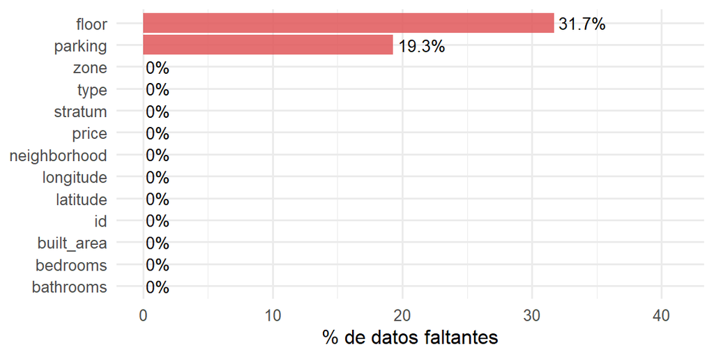

```r
ggplot(na_df, aes(x = reorder(Variable, Pct), y = Pct)) +
  geom_col(fill = "#E15759", alpha = 0.85) +
  geom_text(aes(label = paste0(Pct, "%")), hjust = -0.1, size = 3.5) +
  coord_flip() +
  theme_minimal(base_size = 12) +
  labs(x = NULL, y = "% de datos faltantes") +
  ylim(0, max(na_df$Pct) * 1.3)
```

`floor` concentra la mayoría de los datos faltantes (no aplica a las casas) y no se usa en los análisis de esta actividad. `parking` sí tiene un volumen relevante de faltantes (19.3%); dado que el ACP y los conglomerados requieren observaciones completas en las variables cuantitativas (`scale()`/`prcomp()` no admiten `NA`), se conservan solo los registros completos en esas variables (`vars_num`) en vez de imputar, ya que no es el objetivo de esta actividad.

```r
completos    <- complete.cases(vivienda[, vars_num])
vivienda_cc  <- vivienda[completos, ]

cat("Registros originales:", nrow(vivienda), "\n")
```

```
## Registros originales: 8322
```

```r
cat("Registros completos para ACP y conglomerados:", nrow(vivienda_cc), "\n")
```

```
## Registros completos para ACP y conglomerados: 6717
```

## 4.5 Valores atípicos

Se identifican valores atípicos univariados con el criterio del rango intercuartílico, tal como se describió en la Unidad 1 en la sesión de Conceptos Generales:

$$LI = Q_1 - 1.5 \times IQR \qquad LS = Q_3 + 1.5 \times IQR$$

**Tabla 4.5.** Número y porcentaje de valores atípicos por variable

```r
detect_outliers <- function(x) {
  x   <- na.omit(x)
  q1  <- quantile(x, 0.25); q3 <- quantile(x, 0.75)
  iqr <- q3 - q1
  li  <- q1 - 1.5 * iqr; ls <- q3 + 1.5 * iqr
  sum(x < li | x > ls)
}

data.frame(
  Variable     = vars_num,
  N_atipicos   = sapply(vars_num, function(v) detect_outliers(vivienda[[v]])),
  Pct_atipicos = sapply(vars_num, function(v)
    round(detect_outliers(vivienda[[v]]) / sum(!is.na(vivienda[[v]])) * 100, 1))
) |>
  kable(col.names = c("Variable", "N atípicos", "% atípicos"), align = c("l", "c", "c")) |>
  kable_styling(bootstrap_options = c("striped", "hover"), full_width = FALSE)
```

|  | Variable | N atípicos | % atípicos |
| --- | --- | --- | --- |
| price | price | 552 | 6.6 |
| built_area | built_area | 382 | 4.6 |
| parking | parking | 567 | 8.4 |
| bathrooms | bathrooms | 72 | 0.9 |
| bedrooms | bedrooms | 888 | 10.7 |

**Figura 4.5.** Distribución de las variables cuantitativas (los puntos rojos son valores atípicos según el criterio IQR)

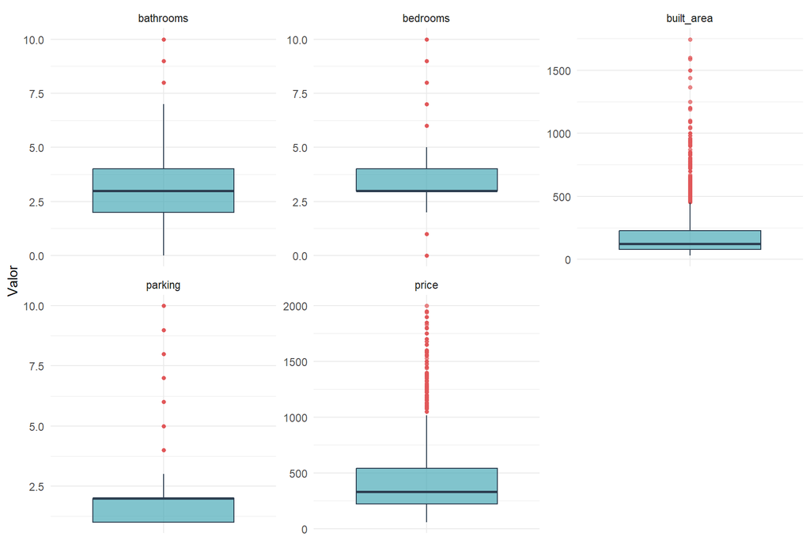

```r
vivienda |>
  select(all_of(vars_num)) |>
  pivot_longer(cols = everything(), names_to = "Variable", values_to = "Valor") |>
  ggplot(aes(x = Variable, y = Valor)) +
  geom_boxplot(fill = col_secundario, color = "#2C3E50",
               outlier.color = "#E15759", outlier.size = 1.2, alpha = 0.7) +
  facet_wrap(~ Variable, scales = "free", ncol = 3) +
  theme_minimal(base_size = 11) +
  theme(axis.text.x = element_blank(), axis.ticks.x = element_blank()) +
  labs(x = NULL, y = "Valor")
```

# 5 Matriz de Correlaciones

## 5.1 Formulación

La matriz de varianzas-covarianzas $\Sigma$ resume la variabilidad conjunta de $p$ variables cuantitativas:

$$\Sigma = \begin{pmatrix}
\sigma_1^2 & \sigma_{12} & \cdots & \sigma_{1p} \\
\sigma_{21} & \sigma_2^2 & \cdots & \sigma_{2p} \\
\vdots & \vdots & \ddots & \vdots \\
\sigma_{p1} & \sigma_{p2} & \cdots & \sigma_p^2
\end{pmatrix}$$

A partir de $\Sigma$ se obtiene la matriz de correlaciones estandarizando por las desviaciones de cada variable, $R = D^{-1/2}\,\Sigma\,D^{-1/2}$, con $D$ la matriz diagonal de varianzas. Cada elemento de $R$ es

$$r_{ij} = \frac{Cov[x_i, x_j]}{\sqrt{Var[x_i]\,Var[x_j]}}, \qquad -1 \le r_{ij} \le 1$$

Como se vio en la Unidad 1 en la sesión de Matriz de Varianza-Covarianza y Correlaciones, valores cercanos a $\pm 1$ indican relación lineal fuerte y valores cercanos a $0$ indican ausencia de relación lineal.

## 5.2 Aplicación a los datos

**Tabla 5.1.** Matriz de correlaciones de las variables de la propiedad

```r
library(corrplot)

Mcor <- cor(vivienda[, vars_num], use = "pairwise.complete.obs")
round(Mcor, 3)
```

```
##            price built_area parking bathrooms bedrooms
## price      1.000      0.687   0.689     0.669    0.264
## built_area 0.687      1.000   0.585     0.648    0.517
## parking    0.689      0.585   1.000     0.571    0.284
## bathrooms  0.669      0.648   0.571     1.000    0.590
## bedrooms   0.264      0.517   0.284     0.590    1.000
```

**Figura 5.1.** Matriz de correlaciones (elipses: magnitud; números: coeficiente)

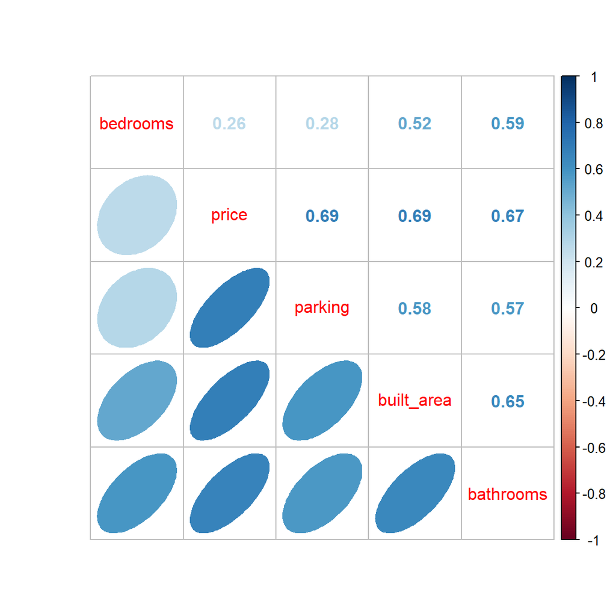

```r
corrplot::corrplot.mixed(Mcor, lower = "ellipse", upper = "number", order = "hclust")
```

`parking` y `built_area` son las variables más asociadas con `price` (correlación de 0.689 y 0.687 respectivamente, prácticamente empatadas), seguidas de `bathrooms` (0.67). `bedrooms` es la que menos se relaciona con el precio (0.26), lo que sugiere que el precio responde más al área y a comodidades como parqueadero que al número de alcobas.

# 6 Análisis de Componentes Principales

## 6.1 Formulación

El primer componente principal es una combinación lineal de las $p$ variables originales, $CP_1 = b_1'X = \sum_{i=1}^{p}\beta_{1i}X_i$, cuya varianza es $V[CP_1] = b_1'\Sigma b_1$, sujeta a la restricción de normalización $b_1'b_1 = 1$. Para maximizarla se usa el método de los multiplicadores de Lagrange:

$$L = b_1'\Sigma b_1 - \lambda_1(b_1'b_1 - 1)$$

Derivando respecto a $b_1$ e igualando a cero:

$$\frac{\partial L}{\partial b_1} = 2\Sigma b_1 - 2\lambda_1 b_1 = 0
\;\;\Longrightarrow\;\; \Sigma b_1 = \lambda_1 b_1$$

Es decir, $b_1$ es un vector propio de $\Sigma$ y $\lambda_1$ su valor propio asociado, que corresponde precisamente a $V[CP_1]$. Los siguientes componentes se obtienen de forma análoga, imponiendo además ortogonalidad ($Cor[CP_i,CP_j]=0$) con los anteriores. La proporción de varianza explicada por el componente $i$ es $\lambda_i \big/ \sum_{k=1}^{p}\lambda_k$ (Unidad 1, sesión de Análisis de Componentes Principales).

## 6.2 Aplicación a los datos

Se estandarizan las variables antes de estimar los componentes (evita que `price`, en millones, domine la varianza frente a variables en otras escalas como `parking`). Se usa el subconjunto de datos completos `vivienda_cc` definido en la Sección 4.4.

```r
library(factoextra)

datos_z  <- scale(vivienda_cc[, vars_num])
res.pca  <- prcomp(datos_z)
res.pca
```

```
## Standard deviations (1, .., p=5):
## [1] 1.8035261 0.9280189 0.6037130 0.5731917 0.4393816
##
## Rotation (n x k) = (5 x 5):
##                  PC1         PC2        PC3         PC4        PC5
## price      0.4662292  0.41483159  0.3565247 -0.19400036  0.6676819
## built_area 0.4821393 -0.04922953  0.4470892  0.66445370 -0.3517537
## parking    0.4353138  0.42903595 -0.7645826  0.17074090 -0.1126544
## bathrooms  0.4857106 -0.16373543  0.1022653 -0.69486790 -0.4939396
## bedrooms   0.3532126 -0.78397071 -0.2792071  0.09418752  0.4168968
```

**Figura 6.1.** Varianza explicada por componente ($\lambda_i/\sum\lambda_k$)

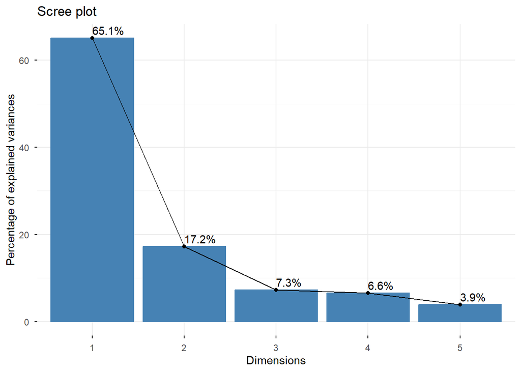

```r
fviz_eig(res.pca, addlabels = TRUE)
```

```r
resumen_var <- summary(res.pca)$importance
round(resumen_var, 3)
```

```
##                          PC1   PC2   PC3   PC4   PC5
## Standard deviation     1.804 0.928 0.604 0.573 0.439
## Proportion of Variance 0.651 0.172 0.073 0.066 0.039
## Cumulative Proportion  0.651 0.823 0.896 0.961 1.000
```

Los dos primeros componentes explican 82.3% de la variabilidad total, lo que permite resumir las 5 variables originales en 2 componentes sin pérdida importante de información.

**Figura 6.2.** Cargas de las variables en los dos primeros componentes (vector propio asociado a cada eje)

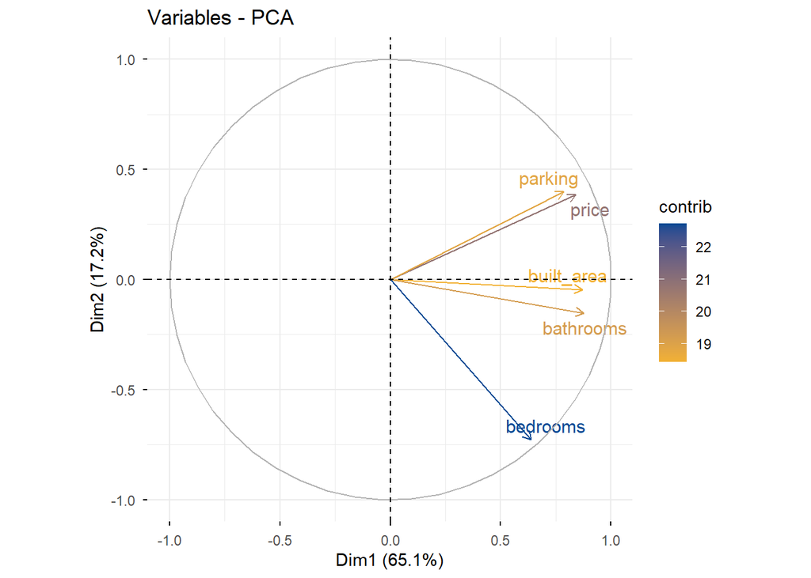

```r
fviz_pca_var(res.pca, col.var = "contrib",
             gradient.cols = c("#F2B134", col_primario), repel = TRUE)
```

El primer componente pondera de forma similar y positiva las 5 variables (cargas entre 0.35 y 0.49): funciona como un eje general de tamaño y precio de la propiedad. El segundo componente contrasta `price` y `parking` (cargas positivas) frente a `bedrooms` (carga negativa dominante, -0.78): separa propiedades caras y con parqueadero de propiedades con muchas alcobas pero menor precio relativo.

**Figura 6.3.** Propiedades en el plano de componentes, coloreadas por tipo de inmueble

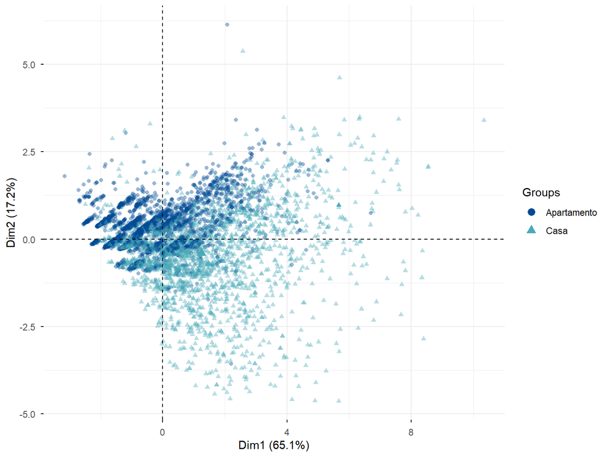

```r
fviz_pca_ind(res.pca, geom = "point", habillage = vivienda_cc$type,
             palette = pal_cat[1:2], alpha.ind = 0.4) +
  labs(title = NULL)
```

Las casas (`type == "Casa"`) se ubican hacia valores más altos del primer componente (propiedades más grandes), mientras que los apartamentos se concentran en valores bajos a medios.

# 7 Análisis de Conglomerados

## 7.1 Formulación

Para que las variables con escalas distintas no dominen el cálculo de distancias, se estandarizan: $z = (x-\bar x)/\sigma$. La distancia euclidiana entre dos propiedades $i,j$ descritas por $m$ variables estandarizadas es

$$d(x_i, x_j) = \sqrt{\sum_{p=1}^{m}(x_{ip}-x_{jp})^2}$$

El método jerárquico agrupa iterativamente los dos elementos (u objetos) más cercanos; el método k-means, en cambio, busca directamente la partición en $k$ grupos que minimiza la suma de cuadrados dentro de cada grupo:

$$\text{WCSS} = \sum_{c=1}^{k}\sum_{i \in c} \lVert x_i - \bar x_c \rVert^2$$

con $\bar x_c$ el centroide del grupo $c$. Para decidir qué tan bien separado queda cada grupo se usa el índice de Silhouette de una observación $i$:

$$s(i) = \frac{b(i)-a(i)}{\max\{a(i), b(i)\}}$$

donde $a(i)$ es la distancia promedio de $i$ a los demás puntos de su propio grupo y $b(i)$ la distancia promedio al grupo vecino más cercano (Unidad 1, sesión de Análisis de Conglomerados).

Para el método jerárquico existen varios criterios de enlace (salto mínimo, salto máximo, promedio y agregación de Ward). Se usa el criterio de **Ward**, que en cada paso fusiona el par de grupos que produce el menor incremento en la WCSS total — el mismo criterio que optimiza k-means — por lo que ambos métodos tienden a ser consistentes entre sí. Otros criterios (como el promedio) son más sensibles a valores atípicos y pueden producir fusiones dominadas por un único punto extremo antes que agrupaciones representativas del conjunto de datos.

## 7.2 Aplicación a los datos

Dado el tamaño de la base (6717 propiedades con datos completos), un dendograma jerárquico sobre la totalidad de los datos sería costoso de calcular y de leer; por eso se usa una muestra para decidir el número de segmentos (el método jerárquico permite determinar el número de clases que luego se usará en un método no jerárquico) y después se aplica k-means sobre la totalidad de los datos.

Se toma una muestra de 300 propiedades y se agrupan con enlace de Ward para estimar, mediante el índice de Silhouette, cuántos segmentos existen.

```r
set.seed(1234)
muestra_idx  <- sample(nrow(datos_z), 300)
muestra_z    <- datos_z[muestra_idx, ]

dist_muestra <- dist(muestra_z, method = "euclidean")
hc_muestra   <- hclust(dist_muestra, method = "ward.D2")
```

**Tabla 7.1.** Índice de Silhouette promedio para distintos valores de k (sobre la muestra de 300, con enlace de Ward)

```r
library(cluster)

sil_k <- sapply(2:6, function(k) {
  grupos <- cutree(hc_muestra, k = k)
  mean(silhouette(grupos, dist_muestra)[, 3])
})

data.frame(k = 2:6, Silhouette = round(sil_k, 3)) |>
  kable(align = c("c", "c")) |>
  kable_styling(bootstrap_options = c("striped", "hover"), full_width = FALSE)
```

| k | Silhouette |
| --- | --- |
| 2 | 0.502 |
| 3 | 0.508 |
| 4 | 0.316 |
| 5 | 0.329 |
| 6 | 0.330 |

```r
k_opt <- (2:6)[which.max(sil_k)]
k_opt
```

```
## [1] 3
```

3 segmentos maximizan el índice de Silhouette en la muestra, por lo que se usa ese valor de k para segmentar la base completa mediante k-means (método no jerárquico, más eficiente para 6717 observaciones que el jerárquico). Para representar gráficamente el dendograma se usa una submuestra más pequeña (n = 40): con 300 hojas el árbol se vuelve ilegible, mientras que con una muestra pequeña se puede seguir visualmente cómo se van fusionando los grupos hasta llegar a los 3 segmentos.

**Figura 7.1.** Dendograma sobre una submuestra (n = 40), coloreado según los 3 segmentos elegidos en la Tabla 7.1

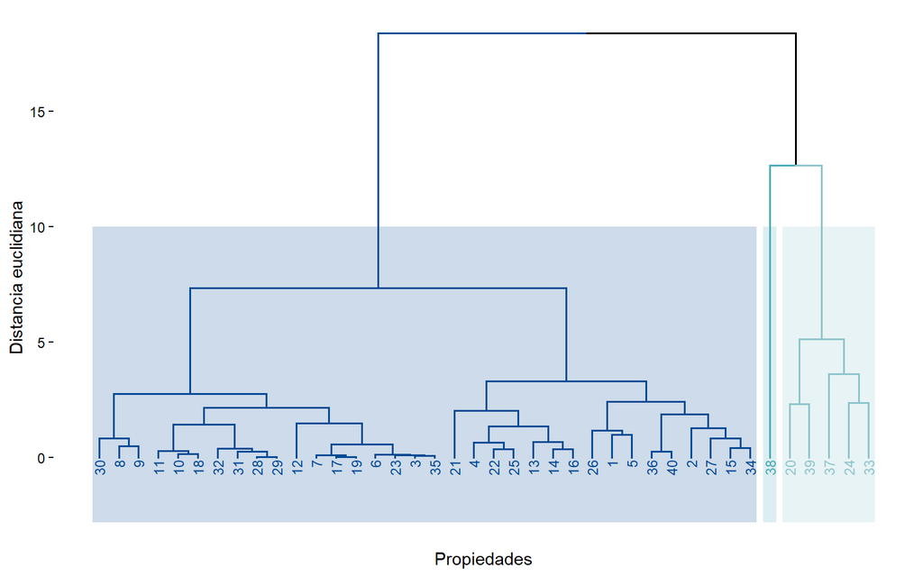

```r
muestra_chica <- muestra_z[sample(nrow(muestra_z), 40), ]
hc_chica <- hclust(dist(muestra_chica, method = "euclidean"), method = "ward.D2")

fviz_dend(hc_chica, k = k_opt, cex = 0.6, k_colors = pal_cat[1:k_opt],
          rect = TRUE, rect_fill = TRUE, rect_border = pal_cat[1:k_opt],
          main = NULL, xlab = "Propiedades", ylab = "Distancia euclidiana")
```

```r
set.seed(1234)
km <- kmeans(datos_z, centers = k_opt, nstart = 25)

vivienda_cc$segment <- factor(km$cluster)
table(vivienda_cc$segment)
```

```
##
##    1    2    3
## 3763 2129  825
```

**Tabla 7.2.** Perfil de cada segmento (medias en la escala original)

```r
etiquetas_segmento <- c("1" = "Económico", "2" = "Medio", "3" = "Premium")

vivienda_cc |>
  group_by(segment) |>
  summarise(across(all_of(vars_num), mean), n = n()) |>
  mutate(across(all_of(vars_num), \(x) round(x, 1)),
         Perfil = etiquetas_segmento[as.character(segment)]) |>
  relocate(Perfil, .after = segment) |>
  kable() |>
  kable_styling(bootstrap_options = c("striped", "hover"), full_width = TRUE)
```

| segment | Perfil | price | built_area | parking | bathrooms | bedrooms | n |
| --- | --- | --- | --- | --- | --- | --- | --- |
| 1 | Económico | 278.9 | 98.5 | 1.3 | 2.3 | 2.9 | 3763 |
| 2 | Medio | 548.5 | 231.9 | 2.0 | 4.1 | 4.5 | 2129 |
| 3 | Premium | 1129.9 | 426.9 | 3.9 | 5.3 | 4.6 | 825 |

**Figura 7.2.** Segmentos en el plano de los dos primeros componentes principales (solo el contorno de cada elipse, sin relleno, para no saturar el área donde los segmentos se tocan)

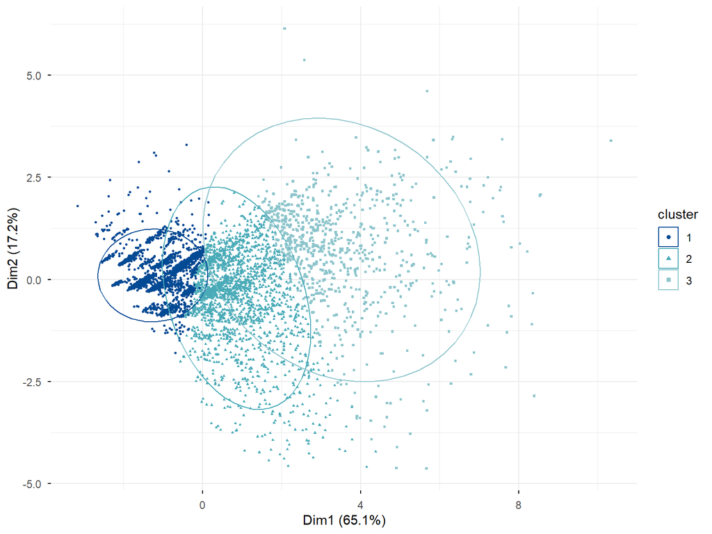

```r
fviz_cluster(list(data = datos_z, cluster = km$cluster),
             geom = "point", pointsize = 0.6,
             palette = pal_cat, ellipse.type = "norm", ellipse.alpha = 0,
             ggtheme = theme_minimal()) +
  labs(title = NULL)
```

Los segmentos se diferencian principalmente por tamaño y precio de la propiedad, en orden creciente: Económico (3763 propiedades), Medio (2129) y Premium (825) (Tabla 7.2). El traslape visible entre segmentos adyacentes en la Figura 7.2 (Económico con Medio, y Medio con Premium) es esperado y no un error: `built_area`, `price` y las demás variables varían de forma continua entre propiedades, no en bloques discretos, por lo que k-means corta ese continuo en tres tramos con fronteras necesariamente difusas. El segmento Premium sí se distingue con claridad del Económico. La relación de estos segmentos con la ubicación geográfica se evalúa formalmente en la Sección 9.

# 8 Análisis de Correspondencia

## 8.1 Formulación

Para dos variables categóricas A y B se construye una tabla de contingencia $n_{ij}$ y se compara con la tabla de frecuencias esperadas bajo independencia, $n_{ij}^{esp} = n_{i.}\,n_{.j}/n$, mediante el estadístico chi-cuadrado de Pearson:

$$\chi^2 = \sum_{i,j} \frac{\left(n_{ij}-n_{ij}^{esp}\right)^2}{n_{ij}^{esp}}$$

A partir de la matriz de discrepancias (o residuos estandarizados) $C$, el análisis de correspondencia factoriza mediante descomposición en valores singulares $C = U D V'$, de donde se obtienen las coordenadas de las filas ($U\sqrt{D}$) y de las columnas ($V\sqrt{D}$) que se representan en el plano factorial, tal como se vio en la Unidad 1 en la sesión de Análisis de Correspondencia.

## 8.2 Zona vs. tipo de inmueble

```r
library(FactoMineR)

tabla_zona_tipo <- table(vivienda$zone, vivienda$type)
tabla_zona_tipo
```

```
##
##                Apartamento Casa
##   Zona Centro           24  100
##   Zona Norte          1198  722
##   Zona Oeste          1029  169
##   Zona Oriente          62  289
##   Zona Sur            2787 1939
```

```r
chisq.test(tabla_zona_tipo)
```

```
##
##  Pearson's Chi-squared test
##
## data:  tabla_zona_tipo
## X-squared = 690.93, df = 4, p-value < 0.00000000000000022
```

```r
# type solo tiene 2 categorías, por lo que el AC entre zone y type tiene un
# único eje (min(filas-1, columnas-1) = 1); no aplica un mapa 2D, se reportan
# las coordenadas de ese único eje
res.ca1 <- CA(tabla_zona_tipo, graph = FALSE)
round(res.ca1$row$coord, 3)
```

```
##  Zona Centro   Zona Norte   Zona Oeste Zona Oriente     Zona Sur
##       -0.861        0.022        0.505       -0.896       -0.048
```

```r
round(res.ca1$col$coord, 3)
```

```
##               [,1]
## Apartamento  0.229
## Casa        -0.363
```

**Figura 8.1.** Proporción de tipo de inmueble por zona

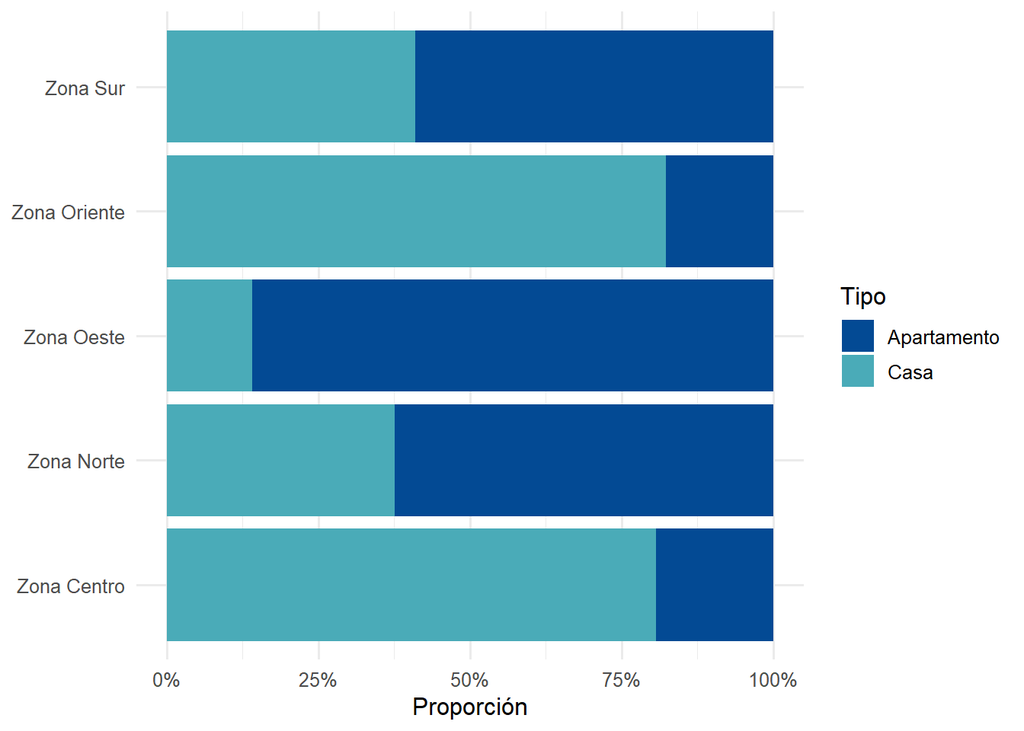

```r
vivienda |>
  filter(!is.na(zone), !is.na(type)) |>
  count(zone, type) |>
  group_by(zone) |>
  mutate(pct = n / sum(n)) |>
  ggplot(aes(x = zone, y = pct, fill = type)) +
  geom_col(position = "fill") +
  scale_fill_manual(values = pal_cat[1:2]) +
  scale_y_continuous(labels = scales::percent) +
  coord_flip() +
  theme_minimal(base_size = 12) +
  labs(x = NULL, y = "Proporción", fill = "Tipo")
```

El p-value rechaza la independencia entre `zone` y `type`. Las coordenadas del único eje del AC y la Figura 8.1 muestran que Zona Oriente y Zona Centro están más asociadas a casas, mientras que Zona Oeste concentra una mayor proporción de apartamentos.

## 8.3 Zona vs. barrio

Dado que `neighborhood` tiene 437 categorías, se conservan los 15 barrios con mayor número de propiedades y se agrupa el resto como “Otros” para que el mapa de correspondencia sea legible.

```r
top_barrios <- vivienda |>
  count(neighborhood, sort = TRUE) |>
  slice_head(n = 15) |>
  pull(neighborhood)

vivienda$neighborhood_grouped <- ifelse(vivienda$neighborhood %in% top_barrios,
                                         vivienda$neighborhood, "Otros")

tabla_zona_barrio <- table(vivienda$zone, vivienda$neighborhood_grouped)
chisq.test(tabla_zona_barrio)
```

```
##
##  Pearson's Chi-squared test
##
## data:  tabla_zona_barrio
## X-squared = 8502.9, df = 60, p-value < 0.00000000000000022
```

**Figura 8.2.** Mapa de correspondencia entre zona y barrio

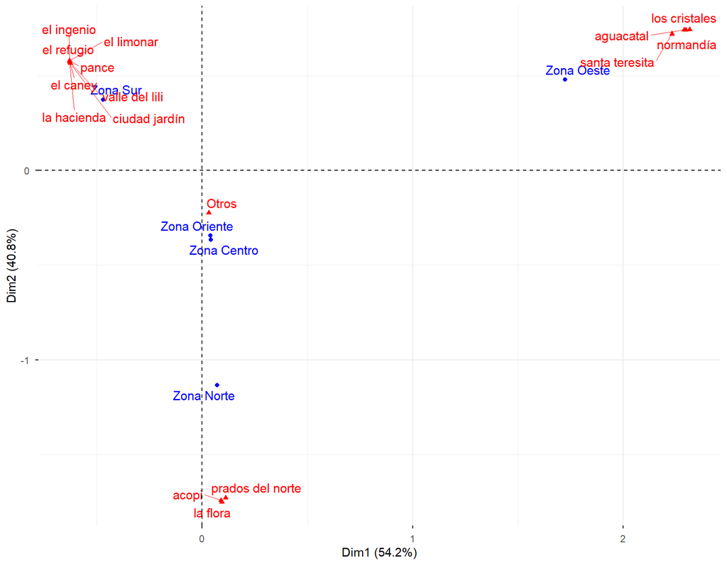

```r
res.ca2 <- CA(tabla_zona_barrio, graph = FALSE)
fviz_ca_biplot(res.ca2, repel = TRUE) + labs(title = NULL)
```

```r
res.ca2$eig
```

```
##          eigenvalue percentage of variance cumulative percentage of variance
## dim 1 0.55448536669           54.249537667                          54.24954
## dim 2 0.41655448536           40.754706258                          95.00424
## dim 3 0.05102153994            4.991826870                          99.99607
## dim 4 0.00004016046            0.003929204                         100.00000
```

Los dos primeros ejes concentran la mayor parte de la varianza explicada, y el mapa evidencia que cada zona tiene barrios característicos, lo cual es esperable dado que los barrios están anidados dentro de una única zona de la ciudad.

# 9 Visualización geográfica

Se usan `longitude` y `latitude` para ubicar las propiedades y contrastar visualmente la zona (Figura 9.2) con el segmento de conglomerados (Figura 9.1). Cada segmento se muestra en un panel separado (en vez de superponer los tres colores en un mismo mapa) porque, al estar presentes en toda la ciudad, los puntos de los tres segmentos se solapan demasiado si se dibujan juntos.

**Figura 9.1.** Ubicación de las propiedades por segmento (un panel por segmento)

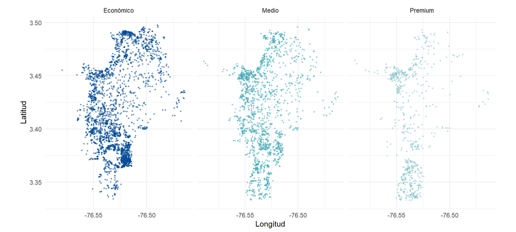

```r
ggplot(vivienda_cc, aes(x = longitude, y = latitude, color = segment)) +
  geom_point(alpha = 0.5, size = 0.6) +
  scale_color_manual(values = pal_cat, labels = etiquetas_segmento) +
  coord_fixed() +
  facet_wrap(~ segment, ncol = 3, labeller = as_labeller(etiquetas_segmento)) +
  theme_minimal(base_size = 11) +
  theme(legend.position = "none") +
  labs(x = "Longitud", y = "Latitud")
```

**Figura 9.2.** Ubicación de las propiedades por zona

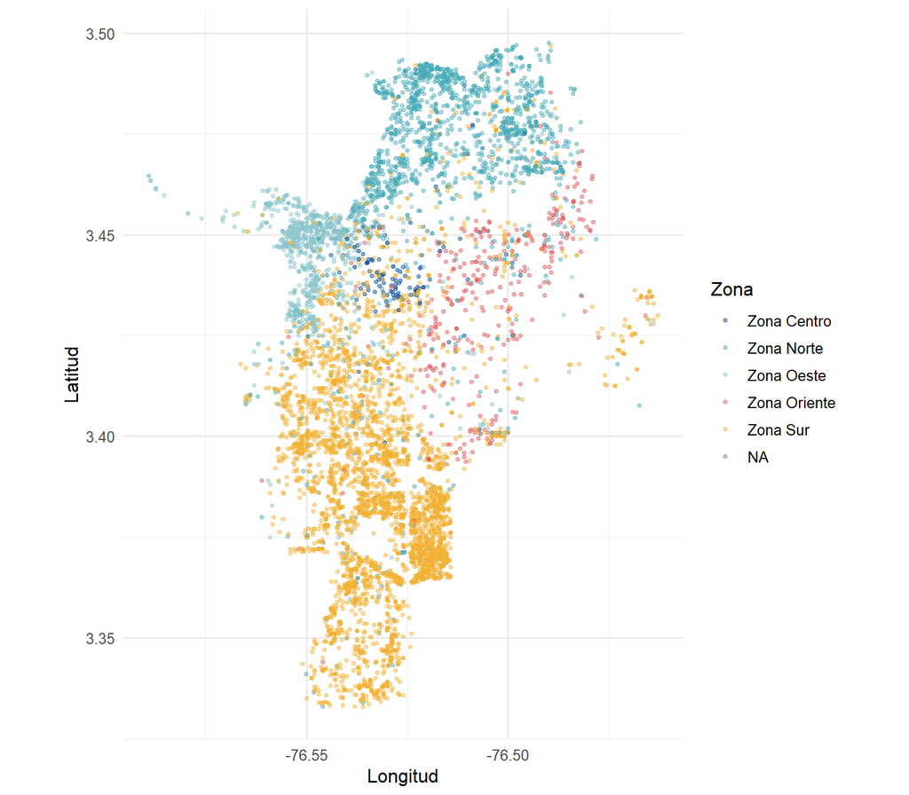

```r
ggplot(vivienda, aes(x = longitude, y = latitude, color = zone)) +
  geom_point(alpha = 0.4, size = 0.8) +
  scale_color_manual(values = pal_cat) +
  coord_fixed() +
  theme_minimal(base_size = 12) +
  labs(x = "Longitud", y = "Latitud", color = "Zona")
```

A simple vista la Figura 9.1 podría sugerir que cada segmento tiene su propia zona, ya que los tres paneles muestran algo de agrupamiento espacial. Sin embargo, el segmento se calculó únicamente con variables físicas de la propiedad (precio, área, parqueaderos, baños, habitaciones) — la ubicación no participó en ese cálculo — por lo que conviene verificar la relación real con una tabla, en vez de comparar los mapas a simple vista.

**Tabla 9.1.** Composición de cada zona por segmento (% de columna)

```r
tab_seg_zona <- table(vivienda_cc$segment, vivienda_cc$zone)
pct_seg_zona <- round(prop.table(tab_seg_zona, margin = 2) * 100, 1) |>
  as.data.frame.matrix()
pct_seg_zona <- cbind(Segmento = etiquetas_segmento[rownames(pct_seg_zona)],
                       pct_seg_zona)

kable(pct_seg_zona, align = c("c", rep("c", 5)), row.names = FALSE) |>
  kable_styling(bootstrap_options = c("striped", "hover"), full_width = FALSE)
```

| Segmento | Zona Centro | Zona Norte | Zona Oeste | Zona Oriente | Zona Sur |
| --- | --- | --- | --- | --- | --- |
| Económico | 46.9 | 65.2 | 40.0 | 44.8 | 58.0 |
| Medio | 50.0 | 27.8 | 39.7 | 52.8 | 29.6 |
| Premium | 3.1 | 7.0 | 20.3 | 2.5 | 12.3 |

```r
chisq.test(tab_seg_zona)
```

```
##
##  Pearson's Chi-squared test
##
## data:  tab_seg_zona
## X-squared = 244.8, df = 8, p-value < 0.00000000000000022
```

La Tabla 9.1 muestra que el segmento Económico domina en Zona Norte (65.2%) y Zona Sur (58.0%); el segmento Medio es más frecuente en Zona Centro (50.0%) y Zona Oriente (52.8%); y el segmento Premium, aunque minoritario en toda la ciudad, se concentra notablemente más en Zona Oeste (20.3% de sus propiedades) que en el resto (2.5% a 12.3%). La prueba chi-cuadrado rechaza la independencia entre segmento y zona ($\chi^2=$ 244.8, p < 0.001). En conclusión, la ubicación **no determina** por sí sola el segmento de una propiedad — los tres segmentos están presentes en las cinco zonas — pero sí existe una asociación real, y Zona Oeste destaca como la zona con mayor concentración relativa de oferta premium.

# 10 Resultados y Recomendaciones

El objetivo de la empresa es claro: usar estos datos para ganar ventaja competitiva, invertir mejor y aumentar la rentabilidad en un mercado que se mueve rápido. Con lo desarrollado en las secciones anteriores respondo aquí a las tres preguntas que realmente le sirven para decidir.

## 10.1 ¿Qué hace que una propiedad valga más?

No es una sola variable, es tamaño construido, número de baños, parqueaderos y habitaciones moviéndose juntos: ese eje único explica el 65% de la variabilidad de toda la oferta (Sección 6, Figura 6.1). El precio en sí no es el mejor indicador para valorar una propiedad de forma aislada — el área construida y el número de parqueaderos lo explican mejor (correlación 0.68 y 0.69, Sección 5). Para tasar o negociar un inmueble, la empresa debería mirar primero estas dos variables antes que compararlo solo por precio de lista.

## 10.2 ¿Cómo segmentar el inventario para no vender todo igual?

El mercado no se divide en dos, se divide en tres: Económico (3763 propiedades, ~279M y 98 m² en promedio), Medio (2129, ~548M y 232 m²) y Premium (825, ~1.130M y 427 m²) (Tabla 7.2). Son solo el 12.3% del inventario pero mueven precios que multiplican por 4 el segmento económico — ahí está el margen, no en el volumen. Tratar estos tres grupos con la misma estrategia comercial es dejar plata sobre la mesa.

**En resumen**: la empresa gana más analizando tamaño de propiedad (no precio de lista), tratando sus tres segmentos por separado, y apostando su inversión premium en Zona Oeste en vez de repartirla parejo por la ciudad.

# 11 Anexos